# Estudios de Informática, Multimedia y Telecomunicaciones

# **PEC2: Estudio de técnicas de visualización de datos**

Autor: Javier García Esteban

Visualización de datos - Semestre 2023.2

# Introducción

En esta actividad deberéis crear tres pequeñas visualizaciones usando técnicas diferentes que os serán asignadas, recibiréis un correo de vuestro profesor con la selección. Cada estudiante tendrá que escoger unos datos idóneos para cada una de las técnicas propuestas y decidir con qué software los crea. Los datos se podrán elegir de cualquier fuente de datos abierta. El estudiante publicará las representaciones en Internet y las presentará en un vídeo.

Para publicar las representaciones os recordamos que es necesario que estas sean accesibles directamente con una URL, sin necesidad de registros ni inicios de sesión. Esto tanto se puede hacer en la misma plataforma donde se ha desarrollado la representación (Flourish, Tableau Public, Infogram, etc), como en un espacio gratuito como github, donde puede crear un proyecto y publicar las representaciones en formato web en github.io, por ejemplo how to github.Links to an external site.

Se trata de familiarizarse con técnicas de visualización y entender la esencia. De hecho, en lugar de ir de los datos a la visualización, en esta actividad lo hacemos a la inversa, es decir, a partir de cada técnica tenemos que ver para qué tipo de datos es adecuado y buscar un conjunto de datos que sea coherente, si puede ser sin tener que hacer ninguna transformación en los datos (para ahorraros trabajo).

En esta actividad hay que publicar las tres técnicas y un video explicativo que sigue el guion siguiente:

1. [Puntos 1 + 2] Presentaos siguiendo el esquema de la PEC 1.
2. [Puntos 1 + 2] [5%] Indicad donde está colgada la visualización para poder acceder.
3. [30%] Definid cada técnica de visualización de forma general: nombre, origen, descripción/funcionamiento, ejemplos de aplicación, etc.
4. [10%] Describid el tipo de datos que se pueden representar con cada técnica ¿(datos cuantitativos, cualitativos? ¿Qué estructura tienen que tener para cada técnica?). Explicad las limitaciones en cuanto a datos (¿hay medida mínima y máxima del juego de datos para cada técnica?).
5. [20%] Haced una representación con cada una de las técnicas usando un conjunto de datos abiertos (más abajo disponéis de algunas fuentes de datos abiertos). En total hay que hacer 3 representaciones simples con 3 conjuntos de datos escogidos por el estudiante.
6. [30%] Comentad brevemente las tres representaciones indicando qué se representa y qué o qué aspectos muestra o demuestra cada representación.
7. [5%] Cada una de las tres presentaciones tienen que tener una duración de unos 2-3 minutos. En total, el video (único) con las tres técnicas no puede exceder los 7 minutos. Se penalizará salir de este rango, porque se valora la capacidad de síntesis y de comunicación.

# 1 - Connected Scatterplot

En este apartado vamos a hablar del diagrama Connected Scatterplot

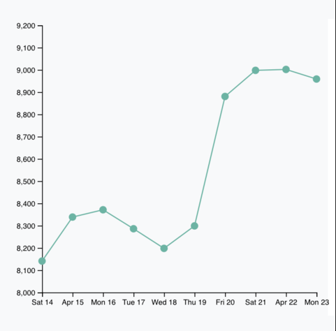

## 1.1 - Cargar el archivo de datos y librerías

Procedemos a leer el archivo de datos y cargamos las librerías necesarias.

Pimero leemos el archivo evolucion_bitcoin_2013_2024_2.csv con la función read.csv. El archivo está en formato inglés separado por comas, por lo que esa función nos sirve:

```r
# Cargamos el archivo de datos
bitcoin_data <- read.csv("evolucion_bitcoin_2013_2024_2.csv", header = TRUE)
bitcoin_data$fecha <- as.Date(bitcoin_data$fecha, format = "%Y-%m-%d")

# Instalamos las librerías necesarias, si no lo estuvieran ya
if (!require("ggplot2", quietly = TRUE)) {
  install.packages("ggplot2")
}
if (!require("dplyr", quietly = TRUE)) {
  install.packages("dplyr")
}
if (!require("hrbrthemes", quietly = TRUE)) {
  install.packages("hrbrthemes")
}

# Usamos librerías
library(ggplot2)
library(dplyr)
library(hrbrthemes)
```

## 1.2 - Generar el diagrama Connected Scatterplot

En segundo lugar, generamos el gráfico Connected Scatterplot para la evolución del bitcoin de 2013 a 2024:

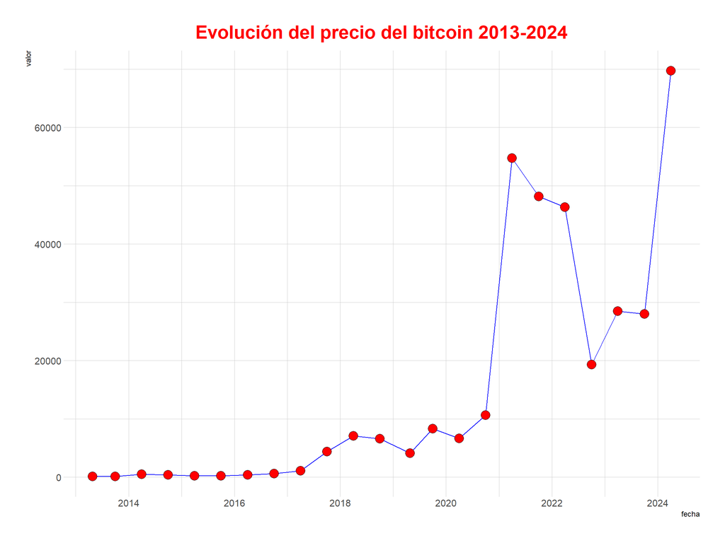

```r
# Connected Scatterplot con ggplot2
bitcoin_data %>%
  tail(24) %>%
  ggplot( aes(x=fecha, y=valor)) +
    geom_line( color="blue") +
    geom_point(shape=21, color="black", fill="red", size=5) +
    theme_ipsum() +
    ggtitle("Evolución del precio del bitcoin 2013-2024") +
    theme(plot.title = element_text(hjust = 0.5, color = "red", size = 22))
```

# 2 - Arc Diagram

En este apartado vamos a hablar del gráfico Arc Diagram.

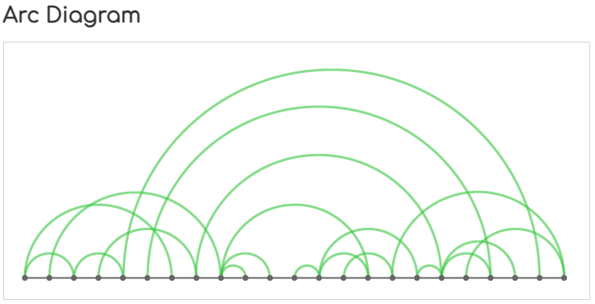

## 2.1 - Carga de librerías

Procedemos cargamos las librerías necesarias.

```r
# instalamos librerías, si no lo estuvieran ya
if (!require("devtools", quietly = TRUE)) {
  install.packages("devtools")
}
if (!require("remotes", quietly = TRUE)) {
  install.packages("remotes")
}
remotes::install_github("gastonstat/arcdiagram")
if (!require("igraph", quietly = TRUE)) {
  install.packages("igraph")
}

# Cargamos librerías
library(devtools)
library(arcdiagram)
library(igraph)
```

## 2.2 - Generamos conjunto de datos con relaciones entre ellos

En segundo lugar, generamos un conjunto de datos (nodos) con conexiones aleatorias entre ellos, para poder generar posteriormente el gráfico:

```r
# Definimos el número de nodos
num_nodos <- 12

# Generamos un orden aleatorio de los nodos
orden_aleatorio <- sample(1:num_nodos)

# Creamos un grafo estrella con el orden aleatorio de nodos
star_graph <- graph.star(num_nodos, mode = "out", center = orden_aleatorio[1])

# Asignamos nombres a los nodos
V(star_graph)$name <- paste("Alumno", 1:num_nodos)

# Creamos conexiones adicionales entre nodos de forma aleatoria
num_conexiones_adicionales <- 8

for (i in 1:num_conexiones_adicionales) {
  nodo_origen <- sample(1:num_nodos, 1)
  nodo_destino <- sample(1:num_nodos, 1)
  while (nodo_destino == nodo_origen || are.connected(star_graph, nodo_origen, nodo_destino)) {
    nodo_destino <- sample(1:num_nodos, 1)
  }
  star_graph <- star_graph + edge(nodo_origen, nodo_destino)
}

# Extraemos la lista de aristas
star_edges <- get.edgelist(star_graph)

# Inspeccionamos el conjunto de datos generado
print(star_edges)
```

```
##       [,1]        [,2]
##  [1,] "Alumno 4"  "Alumno 1"
##  [2,] "Alumno 4"  "Alumno 2"
##  [3,] "Alumno 4"  "Alumno 3"
##  [4,] "Alumno 4"  "Alumno 5"
##  [5,] "Alumno 4"  "Alumno 6"
##  [6,] "Alumno 4"  "Alumno 7"
##  [7,] "Alumno 4"  "Alumno 8"
##  [8,] "Alumno 4"  "Alumno 9"
##  [9,] "Alumno 4"  "Alumno 10"
## [10,] "Alumno 4"  "Alumno 11"
## [11,] "Alumno 4"  "Alumno 12"
## [12,] "Alumno 1"  "Alumno 12"
## [13,] "Alumno 3"  "Alumno 5"
## [14,] "Alumno 3"  "Alumno 1"
## [15,] "Alumno 6"  "Alumno 3"
## [16,] "Alumno 7"  "Alumno 12"
## [17,] "Alumno 11" "Alumno 4"
## [18,] "Alumno 11" "Alumno 1"
## [19,] "Alumno 12" "Alumno 1"
```

## 2.3 - Generar el diagrama Arc Diagram

Por último, generamos el gráfico Arc Diagram

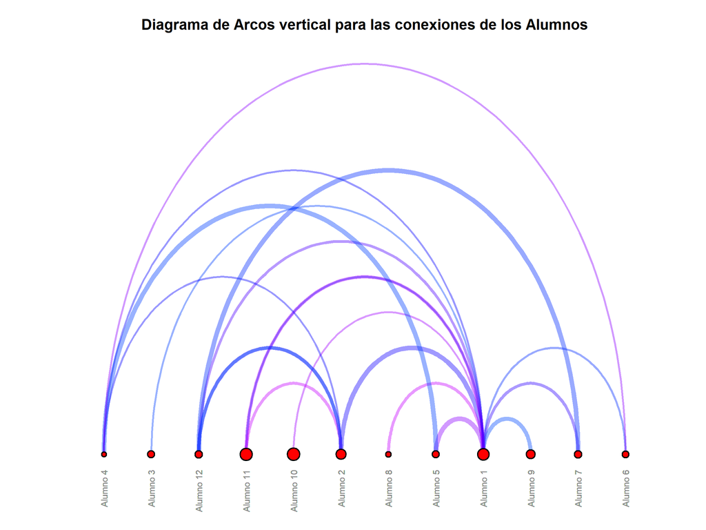

```r
# Generamos el Arc Diagram para el conjunto de datos
set.seed(120)
arcplot(star_edges, ordering = orden_aleatorio, labels = V(star_graph)$name,
        lwd.arcs = 4 * runif(num_nodos, .5, 2), col.arcs = hsv(runif(num_nodos - 1, 0.6, 0.8), alpha = 0.4),
        show.nodes = TRUE, pch.nodes = 21, cex.nodes = runif(num_nodos, 1, 3),
        col.nodes = "black", bg.nodes = "red", lwd.nodes = 2)
# Agregar título al gráfico
title(main = "Diagrama de Arcos vertical para las conexiones de los Alumnos", cex.main = 1.5)
```

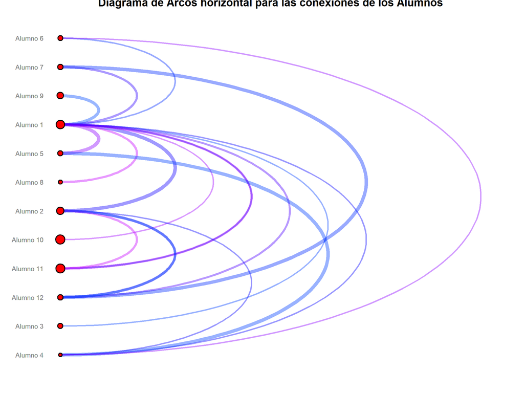

```r
# Generamos el Arc Diagram para el conjunto de datos
set.seed(120)
op = par(mar = c(0.5, 5, 0.5, 3))
arcplot(star_edges, ordering = orden_aleatorio, horizontal=FALSE, labels = V(star_graph)$name,
        lwd.arcs = 4 * runif(num_nodos, .5, 2), col.arcs = hsv(runif(num_nodos - 1, 0.6, 0.8), alpha = 0.4),
        show.nodes = TRUE, pch.nodes = 21, cex.nodes = runif(num_nodos, 1, 3),
        col.nodes = "black", bg.nodes = "red", lwd.nodes = 2)
# Agregar título al gráfico
title(main = "Diagrama de Arcos horizontal para las conexiones de los Alumnos", cex.main = 1.5)
```

# 3 - Cartogramas

En este apartado vamos a hablar del tipo de visualización Cartograma.

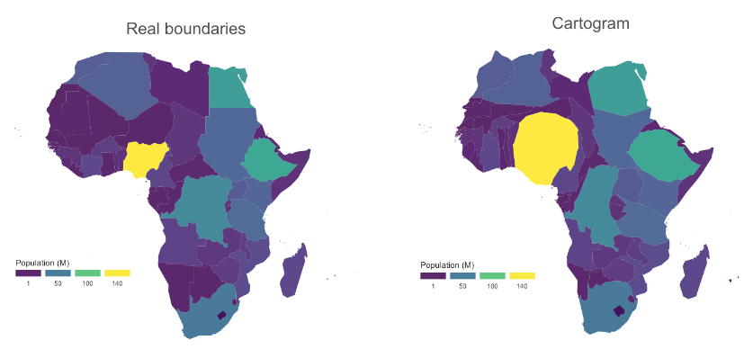

## 3.1 - Cargamos las librerías

Procedemos a leer el archivo de datos y cargamos las librerías necesarias.

```r
# instalamos librerías, si no lo estuvieran ya
if (!require("sf", quietly = TRUE)) {
  install.packages("sf")
}
if (!require("dplyr", quietly = TRUE)) {
  install.packages("dplyr")
}
if (!require("ggplot2", quietly = TRUE)) {
  install.packages("ggplot2")
}
if (!require("mapSpain", quietly = TRUE)) {
  install.packages("mapSpain")
}
if (!require("cartogram", quietly = TRUE)) {
  install.packages(cartogram)
}
if (!require("RColorBrewer", quietly = TRUE)) {
  install.packages(RColorBrewer)
}

# Librerías para generar el Cartograma con ggplot2
library(sf)
library(dplyr)
library(ggplot2)
library(mapSpain)
library(cartogram)
library(RColorBrewer)
```

## 3.2 - Generamos los datos necesarios para los Cartograms

En segundo lugar cargamos los datos

```r
# Cartograma con ggplot2

# Datos
prov <- esp_get_prov() %>%
  mutate(name = prov.shortname.en) %>%
  select(name, cpro)

# Cambiar el CRS
prov_3857 <- st_transform(prov, 3857)

# Agregar
pob_provincias <- mapSpain::pobmun19 %>%
  group_by(cpro) %>%
  summarise(n_pop = sum(pob19))

prov_3857_datos <- prov_3857 %>%
  left_join(pob_provincias, by = c("cpro"))

# Función de etiquetado
label_fun <- function(breaks) {
  labels <- breaks / 1000000
  return(labels)
}

# Datos Cartograma Dorling

prov_3857_datos_cartog_dorling <-
  cartogram_dorling(prov_3857_datos,
                    weight = "n_pop")
```

## 3.3 - Generamos el diagrama Cartograms

Finalmente, generamos el Cartograma con la librería ggplot2

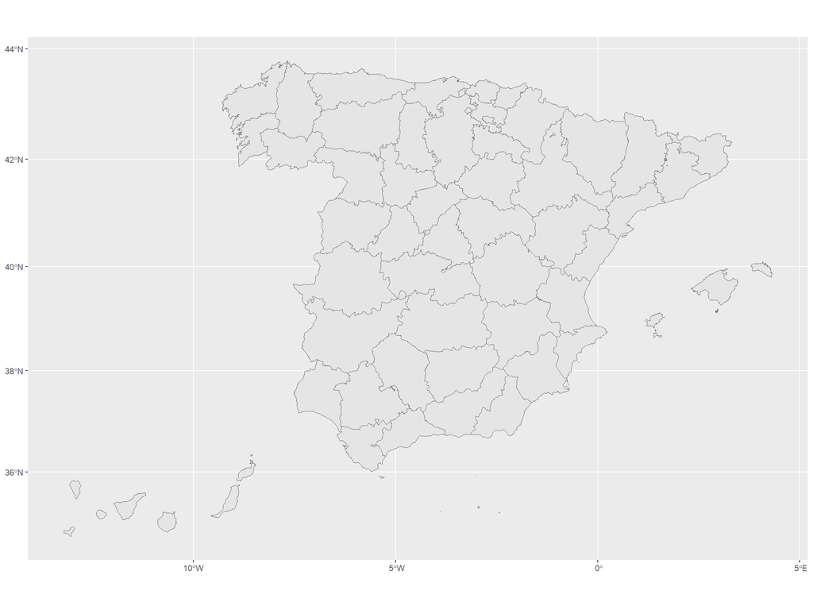

```r
# Cartograma con ggplot2

# Mapa provicias
ggplot(prov_3857) +
  geom_sf()
```

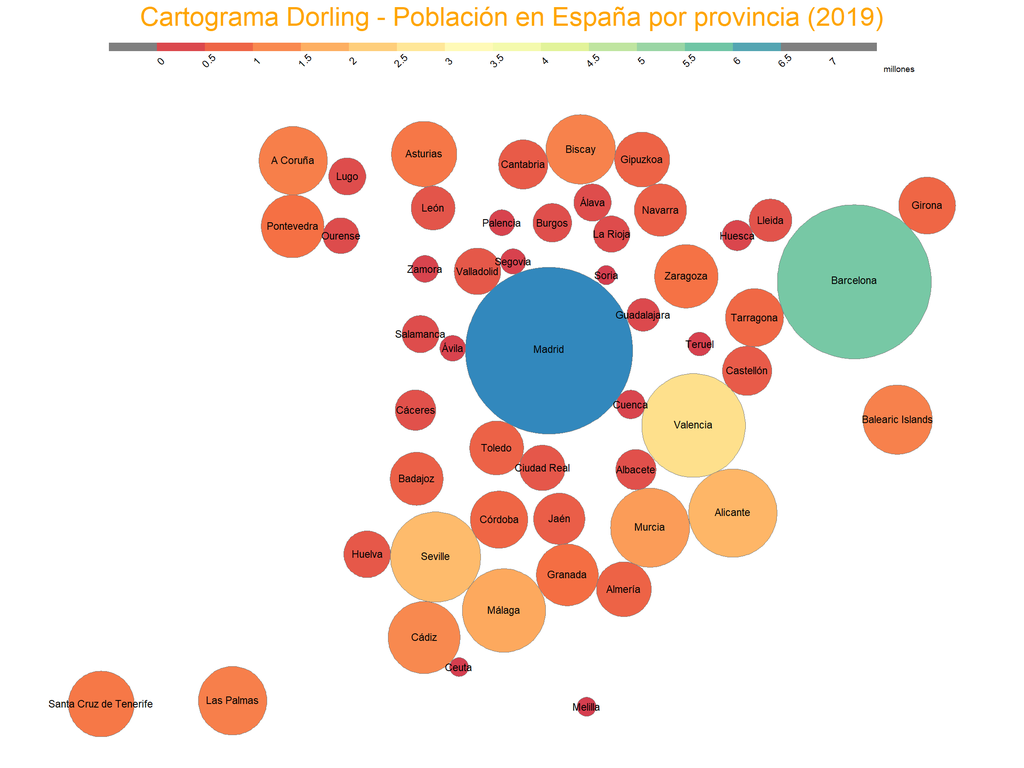

```r
ggplot(prov_3857_datos_cartog_dorling) +
  geom_sf(aes(fill = n_pop), color = "grey50") +
  geom_sf_text(aes(label = name), size = 3, colour = "black") +
  scale_fill_gradientn(
    colours = brewer.pal(9, "Spectral"),
    labels = label_fun,
    n.breaks = 15,
    guide = guide_colorsteps(
      barwidth = 45,
      barheight = 0.5,
      title = "millones",
      title.position = "right",
      title.vjust = 0.1)) +
  theme_void() +
  theme(legend.position = "top",
        legend.margin = margin(t = 10, b = 2),
        legend.title = element_text(size = 7),
        legend.text = element_text(angle = 45,
                                   margin = margin(t = 5))) +
  labs(title = "Cartograma Dorling - Población en España por provincia (2019)")  +
    theme(plot.title = element_text(hjust = 0.5, color = "orange", size = 22))
```

# Recursos de programación y bibliografía

- Incluimos en este apartado una lista de recursos de programación y bibliografía empleada para realizar esta PEC2 de la asignatura de Visualización de datos:
  - [Material teórico del aula: Visualización de datos](https://aula.uoc.edu/courses/35558)
  - [Espacio de recursos UOC para ciencia de datos](http://datascience.recursos.uoc.edu/es/)
  - [Buscador de código R](https://rseek.org/)
  - [Colección de cheatsheets en R](https://www.rstudio.com/resources/cheatsheets/)
  - [Cartogramas en ggplot2](https://r-charts.com/es/espacial/cartograma-ggplot2/)
  - [Arcdiagram en R](https://github.com/gastonstat/arcdiagram)
  - [Connected scatterplot with R and ggplot2](https://r-graph-gallery.com/connected_scatterplot_ggplot2.html)
  - [Dataviz catalogue](https://datavizcatalogue.com/)
  - [Dataviz Project](https://datavizproject.com)
  - [Data to Viz](https://www.data-to-viz.com/)